# DB_elections_REPORT_0522_DATASCIENCE

NDBI048 - Data Science  
Author: Ing. Doudou BA  
Professor: Doc. RnDr. Irena Holubova, Ph.D.  
Charles University  
Prague May 2022

```python
#Contents
#1 Introduction
#1.1 Assignment . . . . . . . . . . . . . . . . . . . . . . . . . . . . . . . . . . . . . . . . .
#1.2 Methodology . . . . . . . . . . . . . . . . . . . . . . . . . . . . . . . . . . . . . . . .
#2. Data Understanding
#2.1. Raw data description . . . . . . . . . . . . . . . . . . . . . . . . . . . . . . . . . . . .
#3 Data Preparation
#3.1 Data Preprocessing - cleaning - Transformation . . . . . . . . . . . . . . . . . . . . .
#3.2 Data Exploration . . . . . . . . . . . . . . . . . . . . . . . . . . . . . . . . . . . . . .
#3.3 Visualization . . . . . . . . . . . . . . . . . . . . . . . . . . . . . . . . . . . . . . . .
#4 Modelling
#5 Evaluation
#6 Conclusion
```

## 1. Introduction

```python
import datetime
from tqdm.notebook import tqdm
from sklearn.model_selection import train_test_split
from sklearn.tree import DecisionTreeClassifier
from sklearn.ensemble import AdaBoostClassifier
from sklearn.metrics import roc_auc_score
import pandas as pd
import os
import numpy as np
from sklearn.datasets import make_classification
from sklearn.model_selection import RepeatedStratifiedKFold
from sklearn.model_selection import GridSearchCV
import matplotlib.pyplot as plt
from sklearn.linear_model import LogisticRegression, LinearRegression
from sklearn.model_selection import cross_val_score
import statsmodels.api as sm
import statsmodels.formula.api as smf
pd.set_option("display.precision", 2)
plt.rcParams['figure.figsize'] = [8, 6]
```

```python
# set width of Jupyter notebook
from IPython.core.display import HTML
display(HTML("<style>.container { width:70% !important; }</style>"))

# set some visual properties of displaying pandas DataFrame
pd.options.display.max_columns=200
pd.options.display.max_rows=200
```

In this report we will explore the Elections dataset. The dataset is provided in two files volby.sav and **volby.csv** with same contents in SPSS native format.

**• Context:** For the purpose of organizing voting at parliamentary elections, Czech Republic is split into around 15 thousands small areas called ELECTION DISTRICTS. It should not be confused with large areas that are also referred to as ”districts.” In a village or generally in a very small municipality, there can be only one election district for the whole municipality. In big cities like Prague there are hundreds or maybe more districts within a city. There are higher levels above municipalities: county (”okres”) and region (”kraj”). So the hierarchy used in data is: district - municipality - county - region.

**• Voting and valid votes:** In the district room, each eligible voter gets an envelope. He/she may put a voting sheet into the envelope and throw the envelope into the ballot box. Not all envelopes may be considered to be valid. So number of envelopes issued >= number of envelopes inside the box = number of valid votes, but the differences are very small.

**• Parties:** Parties in 2013 and 2017 elections had different numbers and sometimes slightly different names. The matching of parties between 2013 and 2017 is below.

**• Population descriptors:** Descriptors of population in particular districts comes from the census 2011, so it is considered valid for both election periods (however the reality could change during these years).

##### 1.1 Scenario

We want to build a model that predicts the **Weights** of political partys given their scores and population information.

##### 1.2 Data collection

The data is collected from trusted sources from dedicated governmental organs.

## 2. Data Understanding

The Data Preparation include the preprocessing, the cleaning and transformation of raw data to  
clean data that will be used as input data in our model.  
The Raw data is loaded in Power BI desktop in UTF8 encoding (to enable the reading of special  
characters) and using Power query we perform the data tranformation.  
The Raw data (dirty data) is as follows:

```python
#%pip install openpyxl
#%pip install xlrd
df1= pd.read_csv(r'/Users/dbcooper/Downloads/archive (2)/volby.csv',encoding='latin-1')
```

##### 2.1 Rows

Election districts in the Czech republic. The district can be identified either by IDN or by ”OBEC Okrsek” (combination of the municipality code and the district number within the municipality). Each district is aligned to one municipality, each municipality to one county, each county to one region

```python
# Print some numbers about data sample size
print(f'Number of rows:   {df1.shape[0]:,}'.replace(',', ' '))
print(f'Number of unique indexes:   {df1.index.nunique():,}'.replace(',', ' '))
print(f'Number of columns:   {df1.shape[1]:,}'.replace(',', ' '))
```

```
Number of rows:   14 764
Number of unique indexes:   14 764
Number of columns:   183
```

```python
# define list of predictors
cols_pred = list(df1.columns[1:-4])
# define list of numerical predictors
cols_pred_num = [col for col in cols_pred if df1[col].dtype != 'O']
# define list of categorical predictors
cols_pred_cat = [col for col in cols_pred if df1[col].dtype == 'O']

print('Numerical predictors:')
print('---------------------')
print(df1[cols_pred_num].dtypes)
print()
print('Categorical predictors:')
print('-----------------------')
print(df1[cols_pred_cat].dtypes)
```

```
Numerical predictors:
---------------------
OBEC                                                int64
Obec_okrsek_final2016                             float64
PAR_2017_1_ObÄanskÃ.demokratickÃ.strana          float64
PAR_2017_2_Å.Ã.dnÃ.rodaVlasteneckÃ.unie           float64
PAR_2017_3_CESTAODPOVÄDNÃ.SPOLEÄNOSTI           float64
PAR_2017_4_ÄeskÃ.str.sociÃ.lnÄ.demokrat          float64
PAR_2017_5_VoltePr.Blokwww.cibulka.net            float64
PAR_2017_6_RadostnÃ.Äesko                        float64
PAR_2017_7_STAROSTOVÃ.ANEZÃ.VISLÃ                float64
PAR_2017_8_KomunistickÃ.str.ÄechaMoravy          float64
PAR_2017_9_StranazelenÃ.ch                        float64
PAR_2017_10_ROZUMNÃstopmigracidiktÃ.t.EU         float64
PAR_2017_11_SpoleÄ.protivÃ.st.vProk.ÃºdolÃ.      float64
PAR_2017_12_StranasvobodnÃ.chobÄanÅ¯             float64
PAR_2017_13_Blokprotiislam.Obran.domova           float64
PAR_2017_14_ObÄanskÃ.demokratickÃ.aliance        float64
PAR_2017_15_ÄeskÃ.pirÃ.tskÃ.strana               float64
PAR_2017_16_OBÄANÃ.2011SPRAVEDL.PROLIDI          float64
PAR_2017_17_UnieH.A.V.E.L                         float64
PAR_2017_18_ÄeskÃ.nÃ.rodnÃ.fronta                float64
PAR_2017_19_ReferendumoEvropskÃ.unii              float64
PAR_2017_20_TOP09                                 float64
PAR_2017_21_ANO2011                               float64
PAR_2017_22_DobrÃ.volba2016                       float64
PAR_2017_23_SPRRepubl.str.Äsl.M.SlÃ.dka          float64
PAR_2017_24_KÅ.esÅ¥.demokr.unieÄs.str.lid        float64
PAR_2017_25_ÄeskÃ.strananÃ.rodnÄ.sociÃ.lnÃ.      float64
PAR_2017_26_REALISTÃ.                             float64
PAR_2017_27_SPORTOVCI                             float64
PAR_2017_28_DÄ.lnic.str.sociÃ.lnÃ.spravedl        float64
PAR_2017_29_Svob.apÅ..dem.T.OkamuraSPD            float64
PAR_2017_30_StranaPrÃ.vObÄanÅ¯                   float64
PAR_2017_31_NÃ.rodSobÄ.                           float64
CelkovÃ.souÄet                                   float64
PAR_2017_1_ObÄanskÃ.demokratickÃ.strana_p        float64
PAR_2017_2_Å.Ã.dnÃ.rodaVlasteneckÃ.unie_p         float64
PAR_2017_3_CESTAODPOVÄDNÃ.SPOLEÄNOSTI_p         float64
PAR_2017_4_ÄeskÃ.str.sociÃ.lnÄ.demokrat._p       float64
```

[output cut: 130 more lines]

```
Vzd_str_be_A                                      float64
Vzd_zakl_A                                        float64
Nab_rimsko_A                                      float64
Eko_zam_A                                         float64
dtype: object

Categorical predictors:
-----------------------
Nazev_obce      object
Okres_nazev     object
Kraj_nazev      object
OBEC_Okrsek     object
CHYBA_KRAJ16    object
PÃ.rovÃ.nÃ.     object
dtype: object
```

##### 2.2 Matching of the parties 2013-2017

The matching is in this structure: Party standard abbreviation, number 2013, number 2017. CSSD, 1, 4 SSO, 2, 12 PIR, 3, 15 TOP, 4, 20 ODS, 6, 1 KDU, 11, 24 PRBL, 12, 5 SPO, 15, 30 SPD, 17, 29 DSSS, 18, 28 ANO, 20, 21 KSCM, 21, 8 SZ, 23, 9. Other parties did not attend both elections or their results were negligible. The data collected in a zip format is extracted and saved in a csv format.

```python
# Importing clean data
data=pd.read_excel(r"/Users/dbcooper/Downloads/clean_data.xlsx")
data.head()
```

|  | ID_N | municiality_code | municipality_name | District_name | Region | municipality_District_code | municipality_District | P1_17 | P2_17 | P3_17 | P4_17 | P5_17 | P6_17 | P7_17 | P8_17 | P9_17 | P10_17 | P11_17 | P12_17 | P13_17 | P14_17 | P15_17 | P16_17 | P17_17 | P18_17 | P19_17 | P20_17 | P21_17 | P22_17 | … |
| --- | --- | --- | --- | --- | --- | --- | --- | --- | --- | --- | --- | --- | --- | --- | --- | --- | --- | --- | --- | --- | --- | --- | --- | --- | --- | --- | --- | --- | --- | --- |
| 0 | 35 | 529478 | Čakov | Benešov | Středočeský kraj | 5.29e+06 | 529478_1 | 7.0 | 0.0 | 0.0 | 6.0 | 0.0 | 0.0 | 8.0 | 3.0 | 0.0 | 0.0 | 0.0 | 2.0 | 0.0 | 0.0 | 6.0 | 0.0 | 0.0 | 0.0 | 0.0 | 8.0 | 15.0 | 0.0 | … |
| 1 | 38 | 529486 | Čechtice | Benešov | Středočeský kraj | 5.29e+06 | 529486_3 | 6.0 | 0.0 | 0.0 | 2.0 | 0.0 | 0.0 | 2.0 | 5.0 | 0.0 | 0.0 | 0.0 | 0.0 | 0.0 | 0.0 | 1.0 | 0.0 | 0.0 | 0.0 | 0.0 | 1.0 | 6.0 | 0.0 | … |
| 2 | 39 | 529486 | Čechtice | Benešov | Středočeský kraj | 5.29e+06 | 529486_4 | 3.0 | 0.0 | 0.0 | 2.0 | 0.0 | 0.0 | 3.0 | 6.0 | 0.0 | 1.0 | 0.0 | 0.0 | 0.0 | 0.0 | 6.0 | 0.0 | 1.0 | 0.0 | 0.0 | 0.0 | 25.0 | 0.0 | … |
| 3 | 41 | 529486 | Čechtice | Benešov | Středočeský kraj | 5.29e+06 | 529486_6 | 1.0 | 0.0 | 0.0 | 6.0 | 0.0 | 0.0 | 5.0 | 13.0 | 2.0 | 0.0 | 0.0 | 0.0 | 0.0 | 0.0 | 2.0 | 0.0 | 0.0 | 0.0 | 0.0 | 2.0 | 13.0 | 0.0 | … |
| 4 | 51 | 529621 | Divišov | Benešov | Středočeský kraj | 5.30e+06 | 529621_5 | 1.0 | 0.0 | 0.0 | 3.0 | 0.0 | 0.0 | 3.0 | 4.0 | 0.0 | 0.0 | 0.0 | 0.0 | 0.0 | 0.0 | 8.0 | 0.0 | 0.0 | 0.0 | 0.0 | 2.0 | 22.0 | 0.0 | … |

```python
desc=data.describe()
desc
```

|  | ID_N | municiality_code | municipality_District_code | P1_17 | P2_17 | P3_17 | P4_17 | P5_17 | P6_17 | P7_17 | P8_17 | P9_17 | P10_17 | P11_17 | P12_17 | P13_17 | P14_17 | P15_17 | P16_17 | P17_17 | P18_17 | P19_17 | P20_17 | P21_17 | P22_17 | P23_17 | P24_17 | P25_17 | P26_17 | … |
| --- | --- | --- | --- | --- | --- | --- | --- | --- | --- | --- | --- | --- | --- | --- | --- | --- | --- | --- | --- | --- | --- | --- | --- | --- | --- | --- | --- | --- | --- | --- |
| count | 14764.00 | 14764.00 | 1.37e+04 | 14745.00 | 14745.00 | 14745.00 | 14745.00 | 14745.00 | 14745.00 | 14745.00 | 14745.00 | 14745.00 | 14745.00 | 14745.00 | 14745.00 | 14745.00 | 14745.00 | 14745.00 | 14745.00 | 14745.00 | 1.47e+04 | 14745.00 | 14745.00 | 14745.00 | 14745.00 | 14745.00 | 14745.00 | 14745.00 | 14745.00 | … |
| mean | 7402.19 | 557082.91 | 1.63e+07 | 38.71 | 0.59 | 0.25 | 24.93 | 0.03 | 0.26 | 17.71 | 26.64 | 4.99 | 2.48 | 0.03 | 5.35 | 0.34 | 0.54 | 36.87 | 0.02 | 0.03 | 7.87e-03 | 0.29 | 18.01 | 101.61 | 0.25 | 0.67 | 19.85 | 0.11 | 2.43 | … |
| std | 4282.24 | 26029.49 | 2.06e+07 | 36.24 | 1.25 | 0.63 | 18.75 | 0.25 | 0.62 | 19.30 | 19.04 | 5.25 | 2.49 | 0.28 | 5.37 | 0.72 | 0.99 | 32.43 | 0.18 | 0.22 | 1.26e-01 | 0.71 | 23.01 | 69.21 | 0.84 | 1.08 | 22.75 | 0.39 | 2.88 | … |
| min | 1.00 | 500011.00 | 5.00e+06 | 0.00 | 0.00 | 0.00 | 0.00 | 0.00 | 0.00 | 0.00 | 0.00 | 0.00 | 0.00 | 0.00 | 0.00 | 0.00 | 0.00 | 0.00 | 0.00 | 0.00 | 0.00e+00 | 0.00 | 0.00 | 0.00 | 0.00 | 0.00 | 0.00 | 0.00 | 0.00 | … |
| 25% | 3691.75 | 541231.00 | 5.49e+06 | 10.00 | 0.00 | 0.00 | 9.00 | 0.00 | 0.00 | 6.00 | 11.00 | 1.00 | 1.00 | 0.00 | 1.00 | 0.00 | 0.00 | 11.00 | 0.00 | 0.00 | 0.00e+00 | 0.00 | 3.00 | 39.00 | 0.00 | 0.00 | 5.00 | 0.00 | 0.00 | … |
| 50% | 7397.50 | 556904.00 | 5.71e+06 | 29.00 | 0.00 | 0.00 | 22.00 | 0.00 | 0.00 | 12.00 | 23.00 | 3.00 | 2.00 | 0.00 | 4.00 | 0.00 | 0.00 | 29.00 | 0.00 | 0.00 | 0.00e+00 | 0.00 | 10.00 | 95.00 | 0.00 | 0.00 | 13.00 | 0.00 | 2.00 | … |
| 75% | 11115.25 | 577308.00 | 5.97e+06 | 57.00 | 1.00 | 0.00 | 37.00 | 0.00 | 0.00 | 23.00 | 38.00 | 7.00 | 4.00 | 0.00 | 8.00 | 1.00 | 1.00 | 53.00 | 0.00 | 0.00 | 0.00e+00 | 0.00 | 23.00 | 151.00 | 0.00 | 1.00 | 27.00 | 0.00 | 4.00 | … |
| max | 14832.00 | 599999.00 | 6.00e+07 | 431.00 | 29.00 | 7.00 | 225.00 | 10.00 | 12.00 | 359.00 | 170.00 | 50.00 | 27.00 | 12.00 | 57.00 | 12.00 | 16.00 | 380.00 | 4.00 | 10.00 | 9.00e+00 | 33.00 | 304.00 | 445.00 | 55.00 | 14.00 | 426.00 | 8.00 | 40.00 | … |

```python
# Print some numbers about data sample size
print(f'We end up with a dataset of:')
print(f'Number of rows:   {data.shape[0]:,}'.replace(',', ' '))
print(f'Number of unique indexes:   {data.index.nunique():,}'.replace(',', ' '))
print(f'Number of columns:   {data.shape[1]:,}'.replace(',', ' '))
```

```
We end up with a dataset of:
Number of rows:   14 764
Number of unique indexes:   14 764
Number of columns:   88
```

```python
# METADEFINITION
#name of the target column
col_target = "Weight"
# define the list of possible predictors
cols_pred = list(data.drop(columns = 'Weight').columns)
# define list of numerical predictors
cols_pred_num = [col for col in cols_pred if data[col].dtype != 'O']
# define list of categorical predictors
cols_pred_cat = [col for col in cols_pred if data[col].dtype == 'O']

print('Numerical predictors:')
print('---------------------')
print(data[cols_pred_num].dtypes)
print()
print('Categorical predictors:')
print('-----------------------')
print(data[cols_pred_cat].dtypes)
```

```
Numerical predictors:
---------------------
ID_N                            int64
municiality_code                int64
municipality_District_code    float64
P1_17                         float64
P2_17                         float64
P3_17                         float64
P4_17                         float64
P5_17                         float64
P6_17                         float64
P7_17                         float64
P8_17                         float64
P9_17                         float64
P10_17                        float64
P11_17                        float64
P12_17                        float64
P13_17                        float64
P14_17                        float64
P15_17                        float64
P16_17                        float64
P17_17                        float64
P18_17                        float64
P19_17                        float64
P20_17                        float64
P21_17                        float64
P22_17                        float64
P23_17                        float64
P24_17                        float64
P25_17                        float64
P26_17                        float64
P27_17                        float64
P28_17                        float64
P29_17                        float64
P30_17                        float64
P31_17                        float64
Total                         float64
Eligible_voters_17            float64
Envelopes_count_17            float64
Valid_votes_count_17          float64
```

[output cut: 39 more lines]

```
edulevel_1                    float64
Catholics                     float64
Employed                      float64
Retired_Working_part          float64
Unemployed                    float64
Retired_not_working           float64
dtype: object

Categorical predictors:
-----------------------
municipality_name        object
District_name            object
Region                   object
municipality_District    object
dtype: object
```

##### Dropping variables with more than 70% missing values

```python
total = data.isnull().sum().sort_values(ascending = False)
percent = (data.isnull().sum()/data.isnull().count()*100).sort_values(ascending = False)
missing_application_train_data  = pd.concat([total, percent], axis=1, keys=['Total', 'Percent'])
morethan_70perct_missing = missing_application_train_data[missing_application_train_data['Percent'] > 70].index
data.drop(columns = morethan_70perct_missing,inplace=True)
```

#### 2.3. Data Visualization

```python
import re
df=data

col_val_num=re.findall('(P[0-9_]+)|(edu_level_[0-9]+)'," ".join(df.columns.tolist()))

#col_val_num=re.findall('P[0-9_]+'," ".join(df.columns.tolist()))
col_val_num=[i[0]+i[1] for i in col_val_num]
col_val_num.extend(["Catholics", "University","Employed","Unemployed"])
col_val_num[:5]
```

```
['P1_17', 'P2_17', 'P3_17', 'P4_17', 'P5_17']
```

```python
data.head()
```

|  | ID_N | municiality_code | municipality_name | District_name | Region | municipality_District_code | municipality_District | P1_17 | P2_17 | P3_17 | P4_17 | P5_17 | P6_17 | P7_17 | P8_17 | P9_17 | P10_17 | P11_17 | P12_17 | P13_17 | P14_17 | P15_17 | P16_17 | P17_17 | P18_17 | P19_17 | P20_17 | P21_17 | P22_17 | … |
| --- | --- | --- | --- | --- | --- | --- | --- | --- | --- | --- | --- | --- | --- | --- | --- | --- | --- | --- | --- | --- | --- | --- | --- | --- | --- | --- | --- | --- | --- | --- |
| 0 | 35 | 529478 | Čakov | Benešov | Středočeský kraj | 5.29e+06 | 529478_1 | 7.0 | 0.0 | 0.0 | 6.0 | 0.0 | 0.0 | 8.0 | 3.0 | 0.0 | 0.0 | 0.0 | 2.0 | 0.0 | 0.0 | 6.0 | 0.0 | 0.0 | 0.0 | 0.0 | 8.0 | 15.0 | 0.0 | … |
| 1 | 38 | 529486 | Čechtice | Benešov | Středočeský kraj | 5.29e+06 | 529486_3 | 6.0 | 0.0 | 0.0 | 2.0 | 0.0 | 0.0 | 2.0 | 5.0 | 0.0 | 0.0 | 0.0 | 0.0 | 0.0 | 0.0 | 1.0 | 0.0 | 0.0 | 0.0 | 0.0 | 1.0 | 6.0 | 0.0 | … |
| 2 | 39 | 529486 | Čechtice | Benešov | Středočeský kraj | 5.29e+06 | 529486_4 | 3.0 | 0.0 | 0.0 | 2.0 | 0.0 | 0.0 | 3.0 | 6.0 | 0.0 | 1.0 | 0.0 | 0.0 | 0.0 | 0.0 | 6.0 | 0.0 | 1.0 | 0.0 | 0.0 | 0.0 | 25.0 | 0.0 | … |
| 3 | 41 | 529486 | Čechtice | Benešov | Středočeský kraj | 5.29e+06 | 529486_6 | 1.0 | 0.0 | 0.0 | 6.0 | 0.0 | 0.0 | 5.0 | 13.0 | 2.0 | 0.0 | 0.0 | 0.0 | 0.0 | 0.0 | 2.0 | 0.0 | 0.0 | 0.0 | 0.0 | 2.0 | 13.0 | 0.0 | … |
| 4 | 51 | 529621 | Divišov | Benešov | Středočeský kraj | 5.30e+06 | 529621_5 | 1.0 | 0.0 | 0.0 | 3.0 | 0.0 | 0.0 | 3.0 | 4.0 | 0.0 | 0.0 | 0.0 | 0.0 | 0.0 | 0.0 | 8.0 | 0.0 | 0.0 | 0.0 | 0.0 | 2.0 | 22.0 | 0.0 | … |

```python
# Municipality information
df_loc = data.filter("ID_N")

# Election results
df_par17 = data.filter(regex=("(P[0-9_17]+)_17|(ID_N)")).dropna()
df_par13 = data.filter(regex=("(P[0-9_]+)_13|(ID_N)")).dropna()
```

```python
df_par13.head()
```

|  | ID_N | P1_13 | P2_13 | P3_13 | P4_13 | P5_13 | P6_13 | P7_13 | P8_13 | P9_13 | P10_13 | P11_13 | P12_13 | P13_13 | P14_13 | P15_13 | P16_13 | P17_13 | P18_13 | P19_13 | P20_13 | P21_13 | P22_13 | P24_13 |
| --- | --- | --- | --- | --- | --- | --- | --- | --- | --- | --- | --- | --- | --- | --- | --- | --- | --- | --- | --- | --- | --- | --- | --- | --- |
| 0 | 35 | 10.0 | 2.0 | 3.0 | 15.0 | 0.0 | 7.0 | 0.0 | 0.0 | 0.0 | 0.0 | 7.0 | 0.0 | 0.0 | 0.0 | 0.0 | 0.0 | 5.0 | 0.0 | 10.0 | 7.0 | 0.0 | 1.0 | 0.0 |
| 1 | 38 | 9.0 | 0.0 | 5.0 | 0.0 | 1.0 | 4.0 | 0.0 | 0.0 | 0.0 | 0.0 | 4.0 | 0.0 | 0.0 | 0.0 | 0.0 | 0.0 | 0.0 | 0.0 | 4.0 | 4.0 | 0.0 | 1.0 | 0.0 |
| 2 | 39 | 10.0 | 0.0 | 2.0 | 5.0 | 0.0 | 4.0 | 0.0 | 0.0 | 0.0 | 0.0 | 5.0 | 0.0 | 0.0 | 0.0 | 0.0 | 0.0 | 0.0 | 0.0 | 9.0 | 6.0 | 0.0 | 2.0 | 0.0 |
| 3 | 41 | 14.0 | 0.0 | 1.0 | 5.0 | 2.0 | 3.0 | 0.0 | 0.0 | 0.0 | 0.0 | 9.0 | 0.0 | 0.0 | 0.0 | 1.0 | 0.0 | 1.0 | 0.0 | 9.0 | 12.0 | 0.0 | 1.0 | 0.0 |
| 4 | 51 | 6.0 | 0.0 | 4.0 | 6.0 | 0.0 | 1.0 | 0.0 | 0.0 | 0.0 | 0.0 | 6.0 | 0.0 | 0.0 | 0.0 | 1.0 | 0.0 | 6.0 | 0.0 | 12.0 | 16.0 | 0.0 | 2.0 | 0.0 |

```python
col_13=list(df_par13.drop(columns="ID_N").columns)
```

```python
df_13 = df_par13.melt(id_vars=['ID_N'], var_name='Partys', value_name='score')
df_17 = df_par17.melt(id_vars=['ID_N'], var_name='Partys', value_name='score')
df_13.head(), df_17.head()
```

```
(   ID_N Partys  score
 0    35  P1_13   10.0
 1    38  P1_13    9.0
 2    39  P1_13   10.0
 3    41  P1_13   14.0
 4    51  P1_13    6.0,
    ID_N Partys  score
 0    35  P1_17    7.0
 1    38  P1_17    6.0
 2    39  P1_17    3.0
 3    41  P1_17    1.0
 4    51  P1_17    1.0)
```

```python
grp=df_13.drop(columns="ID_N").groupby(['Partys']).agg(np.sum).sort_values(by=['Partys'], ascending=True)
```

```python
df_par13.head()
```

|  | ID_N | P1_13 | P2_13 | P3_13 | P4_13 | P5_13 | P6_13 | P7_13 | P8_13 | P9_13 | P10_13 | P11_13 | P12_13 | P13_13 | P14_13 | P15_13 | P16_13 | P17_13 | P18_13 | P19_13 | P20_13 | P21_13 | P22_13 | P24_13 |
| --- | --- | --- | --- | --- | --- | --- | --- | --- | --- | --- | --- | --- | --- | --- | --- | --- | --- | --- | --- | --- | --- | --- | --- | --- |
| 0 | 35 | 10.0 | 2.0 | 3.0 | 15.0 | 0.0 | 7.0 | 0.0 | 0.0 | 0.0 | 0.0 | 7.0 | 0.0 | 0.0 | 0.0 | 0.0 | 0.0 | 5.0 | 0.0 | 10.0 | 7.0 | 0.0 | 1.0 | 0.0 |
| 1 | 38 | 9.0 | 0.0 | 5.0 | 0.0 | 1.0 | 4.0 | 0.0 | 0.0 | 0.0 | 0.0 | 4.0 | 0.0 | 0.0 | 0.0 | 0.0 | 0.0 | 0.0 | 0.0 | 4.0 | 4.0 | 0.0 | 1.0 | 0.0 |
| 2 | 39 | 10.0 | 0.0 | 2.0 | 5.0 | 0.0 | 4.0 | 0.0 | 0.0 | 0.0 | 0.0 | 5.0 | 0.0 | 0.0 | 0.0 | 0.0 | 0.0 | 0.0 | 0.0 | 9.0 | 6.0 | 0.0 | 2.0 | 0.0 |
| 3 | 41 | 14.0 | 0.0 | 1.0 | 5.0 | 2.0 | 3.0 | 0.0 | 0.0 | 0.0 | 0.0 | 9.0 | 0.0 | 0.0 | 0.0 | 1.0 | 0.0 | 1.0 | 0.0 | 9.0 | 12.0 | 0.0 | 1.0 | 0.0 |
| 4 | 51 | 6.0 | 0.0 | 4.0 | 6.0 | 0.0 | 1.0 | 0.0 | 0.0 | 0.0 | 0.0 | 6.0 | 0.0 | 0.0 | 0.0 | 1.0 | 0.0 | 6.0 | 0.0 | 12.0 | 16.0 | 0.0 | 2.0 | 0.0 |

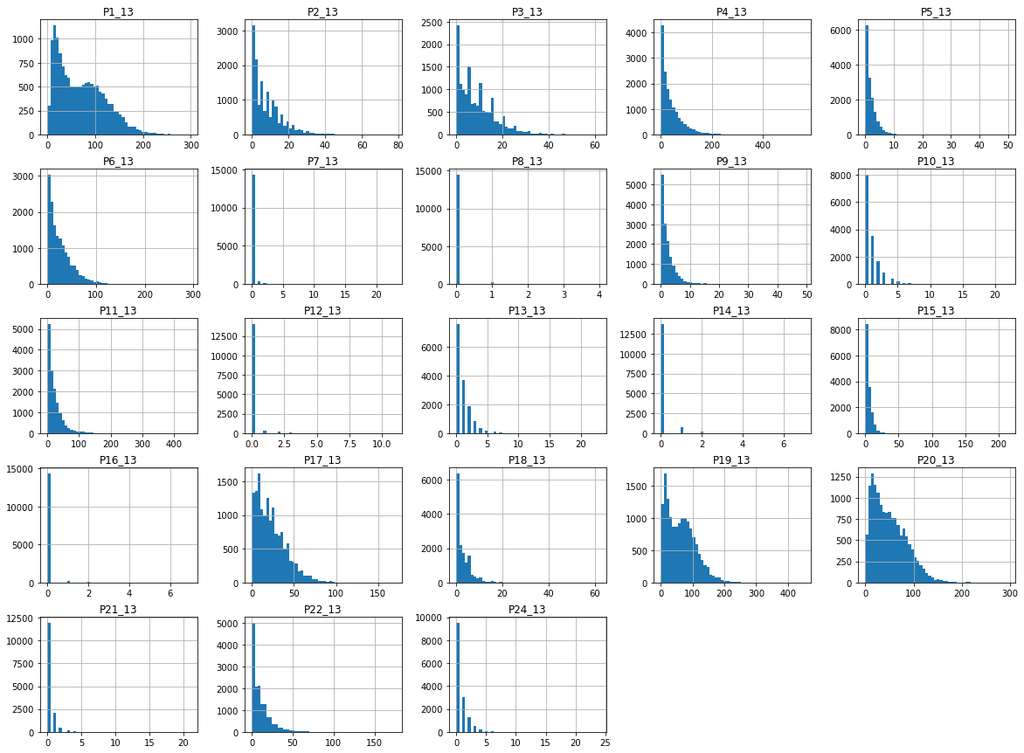

```python
df_par13.drop(columns="ID_N").hist(bins=50, figsize=(20,15))
plt.show()
```

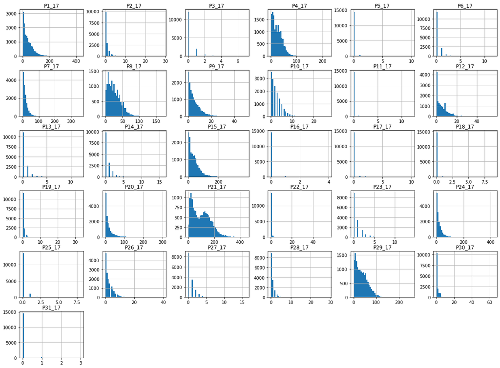

```python
df_par17.drop(columns="ID_N").hist(bins=50, figsize=(20,15))
plt.show()
```

```python
sex_cols=list(["Male", "Female"])
edu_cols=list(["University",	"edu_level_5", "edu_level_4", "edu_level_3", "edu_level_2", "edulevel_1"])
reli_cols=list(["Catholics"])
employ_cols=list(["Employed", "Retired_Working_part", "Unemployed", "Retired_not_working"])
agg_cols=list(["Male", "Female", "University",	"edu_level_5", "edu_level_4", "edu_level_3", "edu_level_2", "edulevel_1","Catholics","Employed", "Retired_Working_part", "Unemployed", "Retired_not_working"])
```

```python
grp_13=df_13.drop(columns="ID_N").groupby(df_13["Partys"]).sum().reset_index()
grp_17=df_17.drop(columns="ID_N").groupby(df_17["Partys"]).sum().reset_index()
grp_13.head(), grp_17.head()
```

```
(   Partys     score
 0  P10_13   13007.0
 1  P11_13  335140.0
 2  P12_13    1225.0
 3  P13_13   13501.0
 4  P14_13    1222.0,
    Partys    score
 0  P10_17  36498.0
 1  P11_17    431.0
 2  P12_17  78933.0
 3  P13_17   5071.0
 4  P14_17   8013.0)
```

```python
import matplotlib.pyplot as plt
import numpy as np
```

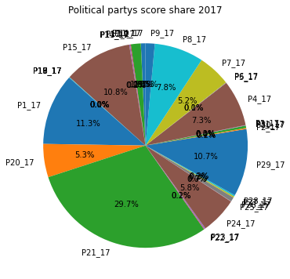

```python
import matplotlib.pyplot as plt
# Pie chart, where the slices will be ordered and plotted counter-clockwise:
labels = grp_17['Partys']
score = grp_17['score']
fig1, ax1 = plt.subplots()
ax1.pie(score, labels=labels, autopct='%1.1f%%',
         startangle=90)
ax1.set_title('Political partys score share 2017')
plt.show()
```

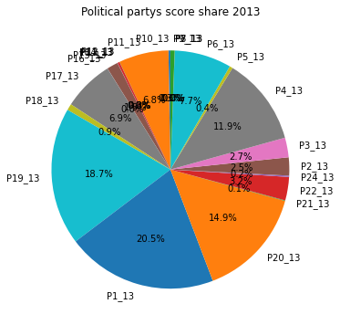

```python
import matplotlib.pyplot as plt
# Pie chart, where the slices will be ordered and plotted counter-clockwise:
labels = grp_13['Partys']
score = grp_13['score']
fig1, ax1 = plt.subplots()
ax1.pie(score, labels=labels, autopct='%1.1f%%',
         startangle=90)
ax1.set_title('Political partys score share 2013')
plt.show()
```

Following histograms give us some insight about the distribution of our features.

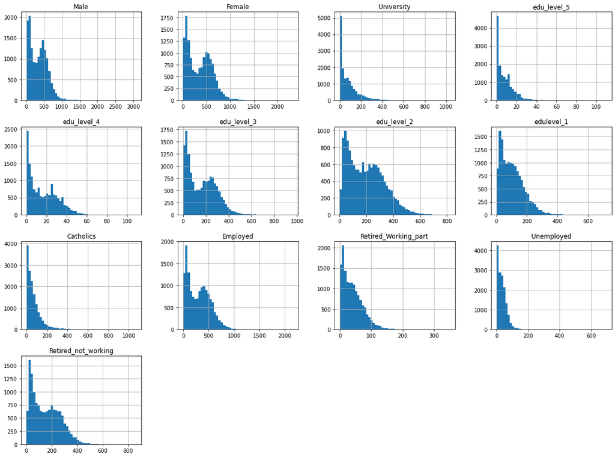

```python
data[agg_cols].hist(bins=50, figsize=(20,15))
plt.show()
```

##### Distribution of the target column

We want to know how well the target is distibuted

```python
data[col_target].head()
```

```
0    0.17
1    0.08
2    0.12
3    0.15
4    0.17
Name: Weight, dtype: float64
```

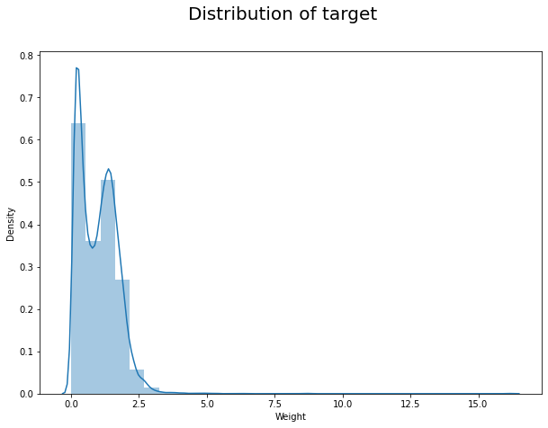

```python
import seaborn as sns

def dist_plot(col):
    plt.figure(figsize=(10,7), facecolor='white')
    sns.distplot(data[col],bins=30,kde=True)
    plt.suptitle("Distribution of target", fontsize=20)
    plt.show()

dist_plot(col_target)
```

### 2.4. Correlation

Now let's explore the relationship between political partys and our demographic features

```python
import seaborn as sns
corr_df = data.corr(method='pearson')
corr_df.style.background_gradient(cmap='coolwarm')
```

|  | ID_N | municiality_code | municipality_District_code | P1_17 | P2_17 | P3_17 | P4_17 | P5_17 | P6_17 | P7_17 | P8_17 | P9_17 | P10_17 | P11_17 | P12_17 | P13_17 | P14_17 | P15_17 | P16_17 | P17_17 | P18_17 | P19_17 | P20_17 | P21_17 | P22_17 | P23_17 | P24_17 | P25_17 | P26_17 | … |
| --- | --- | --- | --- | --- | --- | --- | --- | --- | --- | --- | --- | --- | --- | --- | --- | --- | --- | --- | --- | --- | --- | --- | --- | --- | --- | --- | --- | --- | --- | --- |
| ID_N | 1.00 | 0.10 | 0.14 | 0.18 | -0.03 | 0.07 | 0.26 | 0.22 | 0.05 | -0.03 | 0.15 | 0.27 | 0.02 | 0.17 | 0.19 | 0.05 | 0.04 | 0.26 | 0.05 | -0.11 | 0.09 | 0.05 | 0.24 | 0.19 | 0.09 | 0.01 | 0.39 | -0.01 | 0.17 | … |
| municiality_code | 0.10 | 1.00 | -0.01 | -0.22 | -0.00 | -0.02 | 0.03 | -0.22 | 0.02 | -0.14 | 0.08 | -0.24 | 0.05 | -0.16 | -0.15 | -0.03 | -0.07 | -0.27 | -0.11 | -0.13 | 0.01 | -0.00 | -0.37 | 0.01 | 0.02 | 0.05 | 0.10 | -0.05 | -0.16 | … |
| municipality_District_code | 0.14 | -0.01 | 1.00 | 0.15 | 0.04 | 0.06 | 0.21 | nan | 0.01 | 0.04 | 0.15 | 0.24 | 0.04 | nan | 0.19 | 0.03 | 0.10 | 0.21 | 0.00 | -0.03 | 0.04 | 0.04 | 0.16 | 0.23 | 0.06 | 0.05 | 0.02 | 0.05 | 0.19 | … |
| P1_17 | 0.18 | -0.22 | 0.15 | 1.00 | 0.20 | 0.24 | 0.59 | 0.21 | 0.17 | 0.57 | 0.44 | 0.72 | 0.36 | 0.16 | 0.73 | 0.21 | 0.37 | 0.87 | 0.13 | 0.11 | 0.01 | 0.21 | 0.82 | 0.66 | 0.16 | 0.21 | 0.45 | 0.13 | 0.62 | … |
| P2_17 | -0.03 | -0.00 | 0.04 | 0.20 | 1.00 | 0.07 | 0.24 | -0.01 | 0.07 | 0.19 | 0.25 | 0.16 | 0.22 | 0.01 | 0.22 | 0.12 | 0.13 | 0.21 | 0.03 | 0.05 | 0.00 | 0.09 | 0.12 | 0.29 | 0.04 | 0.15 | 0.12 | 0.03 | 0.16 | … |
| P3_17 | 0.07 | -0.02 | 0.06 | 0.24 | 0.07 | 1.00 | 0.21 | 0.03 | 0.08 | 0.18 | 0.17 | 0.22 | 0.13 | 0.02 | 0.22 | 0.07 | 0.13 | 0.25 | 0.03 | 0.03 | 0.00 | 0.07 | 0.20 | 0.24 | 0.08 | 0.09 | 0.16 | 0.04 | 0.19 | … |
| P4_17 | 0.26 | 0.03 | 0.21 | 0.59 | 0.24 | 0.21 | 1.00 | 0.06 | 0.24 | 0.40 | 0.74 | 0.52 | 0.48 | 0.04 | 0.55 | 0.23 | 0.31 | 0.61 | 0.05 | 0.04 | 0.07 | 0.21 | 0.39 | 0.81 | 0.17 | 0.30 | 0.54 | 0.14 | 0.48 | … |
| P5_17 | 0.22 | -0.22 | nan | 0.21 | -0.01 | 0.03 | 0.06 | 1.00 | -0.01 | 0.09 | 0.00 | 0.23 | 0.01 | 0.24 | 0.17 | 0.04 | 0.05 | 0.28 | 0.16 | 0.05 | -0.01 | 0.03 | 0.33 | 0.04 | 0.01 | -0.01 | 0.05 | 0.04 | 0.15 | … |
| P6_17 | 0.05 | 0.02 | 0.01 | 0.17 | 0.07 | 0.08 | 0.24 | -0.01 | 1.00 | 0.10 | 0.22 | 0.12 | 0.16 | -0.01 | 0.15 | 0.07 | 0.08 | 0.16 | 0.04 | 0.01 | 0.03 | 0.05 | 0.08 | 0.23 | 0.07 | 0.08 | 0.19 | 0.07 | 0.14 | … |
| P7_17 | -0.03 | -0.14 | 0.04 | 0.57 | 0.19 | 0.18 | 0.40 | 0.09 | 0.10 | 1.00 | 0.35 | 0.43 | 0.31 | 0.06 | 0.48 | 0.17 | 0.24 | 0.58 | 0.05 | 0.11 | -0.02 | 0.15 | 0.48 | 0.51 | 0.12 | 0.16 | 0.28 | 0.11 | 0.40 | … |
| P8_17 | 0.15 | 0.08 | 0.15 | 0.44 | 0.25 | 0.17 | 0.74 | 0.00 | 0.22 | 0.35 | 1.00 | 0.38 | 0.50 | -0.00 | 0.45 | 0.24 | 0.27 | 0.47 | 0.03 | 0.04 | 0.06 | 0.20 | 0.23 | 0.78 | 0.16 | 0.33 | 0.38 | 0.14 | 0.38 | … |
| P9_17 | 0.27 | -0.24 | 0.24 | 0.72 | 0.16 | 0.22 | 0.52 | 0.23 | 0.12 | 0.43 | 0.38 | 1.00 | 0.30 | 0.18 | 0.62 | 0.19 | 0.33 | 0.77 | 0.13 | 0.08 | 0.02 | 0.18 | 0.74 | 0.54 | 0.15 | 0.18 | 0.38 | 0.12 | 0.54 | … |
| P10_17 | 0.02 | 0.05 | 0.04 | 0.36 | 0.22 | 0.13 | 0.48 | 0.01 | 0.16 | 0.31 | 0.50 | 0.30 | 1.00 | 0.01 | 0.34 | 0.21 | 0.21 | 0.39 | 0.04 | 0.06 | 0.03 | 0.16 | 0.20 | 0.55 | 0.12 | 0.27 | 0.27 | 0.10 | 0.27 | … |
| P11_17 | 0.17 | -0.16 | nan | 0.16 | 0.01 | 0.02 | 0.04 | 0.24 | -0.01 | 0.06 | -0.00 | 0.18 | 0.01 | 1.00 | 0.15 | 0.03 | 0.04 | 0.22 | 0.12 | 0.02 | -0.01 | 0.02 | 0.26 | 0.02 | 0.00 | 0.00 | 0.04 | 0.03 | 0.12 | … |
| P12_17 | 0.19 | -0.15 | 0.19 | 0.73 | 0.22 | 0.22 | 0.55 | 0.17 | 0.15 | 0.48 | 0.45 | 0.62 | 0.34 | 0.15 | 1.00 | 0.22 | 0.32 | 0.74 | 0.10 | 0.09 | 0.00 | 0.19 | 0.64 | 0.61 | 0.17 | 0.21 | 0.42 | 0.13 | 0.55 | … |
| P13_17 | 0.05 | -0.03 | 0.03 | 0.21 | 0.12 | 0.07 | 0.23 | 0.04 | 0.07 | 0.17 | 0.24 | 0.19 | 0.21 | 0.03 | 0.22 | 1.00 | 0.13 | 0.23 | 0.03 | 0.04 | 0.02 | 0.10 | 0.15 | 0.28 | 0.06 | 0.14 | 0.14 | 0.06 | 0.16 | … |
| P14_17 | 0.04 | -0.07 | 0.10 | 0.37 | 0.13 | 0.13 | 0.31 | 0.05 | 0.08 | 0.24 | 0.27 | 0.33 | 0.21 | 0.04 | 0.32 | 0.13 | 1.00 | 0.35 | 0.07 | 0.03 | 0.00 | 0.11 | 0.29 | 0.36 | 0.08 | 0.16 | 0.19 | 0.07 | 0.27 | … |
| P15_17 | 0.26 | -0.27 | 0.21 | 0.87 | 0.21 | 0.25 | 0.61 | 0.28 | 0.16 | 0.58 | 0.47 | 0.77 | 0.39 | 0.22 | 0.74 | 0.23 | 0.35 | 1.00 | 0.16 | 0.13 | 0.02 | 0.21 | 0.84 | 0.67 | 0.17 | 0.21 | 0.43 | 0.15 | 0.63 | … |
| P16_17 | 0.05 | -0.11 | 0.00 | 0.13 | 0.03 | 0.03 | 0.05 | 0.16 | 0.04 | 0.05 | 0.03 | 0.13 | 0.04 | 0.12 | 0.10 | 0.03 | 0.07 | 0.16 | 1.00 | 0.00 | -0.01 | 0.01 | 0.18 | 0.04 | -0.01 | 0.02 | 0.01 | 0.04 | 0.09 | … |
| P17_17 | -0.11 | -0.13 | -0.03 | 0.11 | 0.05 | 0.03 | 0.04 | 0.05 | 0.01 | 0.11 | 0.04 | 0.08 | 0.06 | 0.02 | 0.09 | 0.04 | 0.03 | 0.13 | 0.00 | 1.00 | -0.01 | 0.04 | 0.12 | 0.06 | -0.00 | 0.02 | -0.02 | 0.01 | 0.06 | … |
| P18_17 | 0.09 | 0.01 | 0.04 | 0.01 | 0.00 | 0.00 | 0.07 | -0.01 | 0.03 | -0.02 | 0.06 | 0.02 | 0.03 | -0.01 | 0.00 | 0.02 | 0.00 | 0.02 | -0.01 | -0.01 | 1.00 | 0.01 | -0.01 | 0.07 | 0.00 | 0.02 | 0.03 | 0.01 | 0.04 | … |
| P19_17 | 0.05 | -0.00 | 0.04 | 0.21 | 0.09 | 0.07 | 0.21 | 0.03 | 0.05 | 0.15 | 0.20 | 0.18 | 0.16 | 0.02 | 0.19 | 0.10 | 0.11 | 0.21 | 0.01 | 0.04 | 0.01 | 1.00 | 0.16 | 0.23 | 0.05 | 0.11 | 0.14 | 0.05 | 0.17 | … |
| P20_17 | 0.24 | -0.37 | 0.16 | 0.82 | 0.12 | 0.20 | 0.39 | 0.33 | 0.08 | 0.48 | 0.23 | 0.74 | 0.20 | 0.26 | 0.64 | 0.15 | 0.29 | 0.84 | 0.18 | 0.12 | -0.01 | 0.16 | 1.00 | 0.42 | 0.11 | 0.10 | 0.32 | 0.12 | 0.56 | … |
| P21_17 | 0.19 | 0.01 | 0.23 | 0.66 | 0.29 | 0.24 | 0.81 | 0.04 | 0.23 | 0.51 | 0.78 | 0.54 | 0.55 | 0.02 | 0.61 | 0.28 | 0.36 | 0.67 | 0.04 | 0.06 | 0.07 | 0.23 | 0.42 | 1.00 | 0.21 | 0.35 | 0.49 | 0.15 | 0.53 | … |
| P22_17 | 0.09 | 0.02 | 0.06 | 0.16 | 0.04 | 0.08 | 0.17 | 0.01 | 0.07 | 0.12 | 0.16 | 0.15 | 0.12 | 0.00 | 0.17 | 0.06 | 0.08 | 0.17 | -0.01 | -0.00 | 0.00 | 0.05 | 0.11 | 0.21 | 1.00 | 0.06 | 0.13 | 0.03 | 0.14 | … |
| P23_17 | 0.01 | 0.05 | 0.05 | 0.21 | 0.15 | 0.09 | 0.30 | -0.01 | 0.08 | 0.16 | 0.33 | 0.18 | 0.27 | 0.00 | 0.21 | 0.14 | 0.16 | 0.21 | 0.02 | 0.02 | 0.02 | 0.11 | 0.10 | 0.35 | 0.06 | 1.00 | 0.14 | 0.06 | 0.16 | … |
| P24_17 | 0.39 | 0.10 | 0.02 | 0.45 | 0.12 | 0.16 | 0.54 | 0.05 | 0.19 | 0.28 | 0.38 | 0.38 | 0.27 | 0.04 | 0.42 | 0.14 | 0.19 | 0.43 | 0.01 | -0.02 | 0.03 | 0.14 | 0.32 | 0.49 | 0.13 | 0.14 | 1.00 | 0.06 | 0.34 | … |
| P25_17 | -0.01 | -0.05 | 0.05 | 0.13 | 0.03 | 0.04 | 0.14 | 0.04 | 0.07 | 0.11 | 0.14 | 0.12 | 0.10 | 0.03 | 0.13 | 0.06 | 0.07 | 0.15 | 0.04 | 0.01 | 0.01 | 0.05 | 0.12 | 0.15 | 0.03 | 0.06 | 0.06 | 1.00 | 0.12 | … |
| P26_17 | 0.17 | -0.16 | 0.19 | 0.62 | 0.16 | 0.19 | 0.48 | 0.15 | 0.14 | 0.40 | 0.38 | 0.54 | 0.27 | 0.12 | 0.55 | 0.16 | 0.27 | 0.63 | 0.09 | 0.06 | 0.04 | 0.17 | 0.56 | 0.53 | 0.14 | 0.16 | 0.34 | 0.12 | 1.00 | … |
| P27_17 | 0.12 | -0.05 | 0.06 | 0.33 | 0.12 | 0.10 | 0.35 | 0.06 | 0.13 | 0.20 | 0.30 | 0.28 | 0.25 | 0.04 | 0.30 | 0.13 | 0.18 | 0.33 | 0.08 | 0.02 | 0.02 | 0.11 | 0.24 | 0.36 | 0.08 | 0.16 | 0.24 | 0.09 | 0.27 | … |

[output cut: 54 more lines]

Results show high correlation between educated people and following political partys: P20, P15, P12, P9, P1 (red) which might lead to think (not causality)  
that they have tendency to vote for those particular political partys. Now we explore the Relationship between religion and decision of voting for a political party Results show high correlation between catholics and political party P24, which is a catholic party.  
Which might lead to think and it is understandable that they vote for P24. *Now we explore relationship between sexe and decision of voting for a particular political party* Result: We found also high correlation between Men as well as Women and party P29, P21, P15, P12, P8, P4, P1 Divorced People have the same tendency as well as Men and Women. People of age over 65 would vote for P1, P4, P21 while Roma People seem not have impact to the elections issues *Relationship between employment status and decision of voting for a particular political party* Conclusion: Retired people with part time job have correlation with P15, P20, P1 and P9 while retired without are correlated with P29, P21,P8 and P4 Unemployed people have correlation with for P29, P21, P7 and P4.

The results of the election of Party 1 has a major impact with political partys P20,P21,P15,P12,P9, P7 and P4 They seem to obviously compete for the same voters Changes of structure of political partys between 2013 and 2017 Results: There is very low corelation for political partys P8, P16, P17, P18 between 2013 and 2017 meaning They probably have changes in their structure between 2013 and 2017 General Conclusion:

Overall correlation we noticed that P24,P29,P20,P21,P15,P12,P9, P7, P4 and P1 are major political partys and have chance to win the elections. We will therefore focus the rest of the analysis on the mentioned political partys

### 3. Data Preparation

##### 3.1 Mean target encoding

We do apply mean target encoding to transform categorical variables into numerical features that we will use as final predictors in our model.

```python
def mean_target_encoding(dt, predictor, target, alpha = 0.01):
    total_cnt = len(dt)
    total_dr = np.mean(dt[target])
    dt_grp = dt.groupby(predictor).agg(
        categ_dr = (target, np.mean),
        categ_cnt = (target, len)
    )

    dt_grp['categ_freq'] = dt_grp['categ_cnt'] / total_cnt
    dt_grp['categ_encoding'] = (dt_grp['categ_freq'] * dt_grp['categ_dr'] + alpha * total_dr) / (dt_grp['categ_freq'] + alpha)

    return dt_grp[['categ_encoding']].to_dict()['categ_encoding']

# METADEFINITION
#name of the target column
col_target = "Weight"
# define the list of possible predictors
cols_pred = list(data.drop(columns = 'Weight').columns)
# define list of numerical predictors
cols_pred_num = [col for col in cols_pred if data[col].dtype != 'O']
# define list of categorical predictors
cols_pred_cat = [col for col in cols_pred if data[col].dtype == 'O']
```

```python
# Save the mean encoding parameters for the test set
list_of_mean_encoding = []
for pred in cols_pred_cat:
    new_vals = mean_target_encoding(
        dt=data,
        predictor=pred,
        target=col_target
    )
    list_of_mean_encoding.append([pred,new_vals])

# encode categorical predictors
for pred in cols_pred_cat:
    new_vals = mean_target_encoding(
        dt=data,
        predictor=pred,
        target=col_target
    )

    additional_values = set(data[data[pred].notnull()][pred].unique()) - set(new_vals.keys())
    for p in additional_values:
        new_vals[p] = total_dr

    data['MTE_' + pred] = data[pred].replace(new_vals)

    if 'MTE_' + pred not in cols_pred:
        cols_pred.append('MTE_' + pred)

    if pred in cols_pred:
        cols_pred.remove(pred)

# Drop all the old categorical variables
data.drop(columns = cols_pred_cat, inplace = True)
```

```python
final_predictors = list(data.drop(columns = col_target).columns)
```

```python
# find columns with infinity values
cols_with_inf = []
for col in final_predictors:
    if np.any(np.isinf(data[col])):
        cols_with_inf.append(col)
        print(f'Column {col} includes infinity values.')

# replace infinity values
for col in cols_with_inf:
    data[col].replace(np.inf, 9999999, inplace = True)


# find columns with NEGATIVE infinity values
cols_with_neginf = []
for col in final_predictors:
    if np.any(np.isneginf(data[col])):
        cols_with_neginf.append(col)
        print(f'Column {col} includes negative infinity values.')

# replace NEGATIVE infinity values
for col in cols_with_neginf:
    data[col].replace(np.inf, 9999999, inplace = True)

# find columns with NaN values ALL
cols_with_nan = []
for col in final_predictors:
    if np.any(np.isnan(data[col])):
        cols_with_nan.append(col)
        print(f'Column {col} includes NaN values.')


# replace NaN values
for col in cols_with_nan:
    data[col].replace(np.nan, 9999999, inplace = True)
```

```
Column municipality_District_code includes NaN values.
Column P1_17 includes NaN values.
Column P2_17 includes NaN values.
Column P3_17 includes NaN values.
Column P4_17 includes NaN values.
Column P5_17 includes NaN values.
Column P6_17 includes NaN values.
Column P7_17 includes NaN values.
Column P8_17 includes NaN values.
Column P9_17 includes NaN values.
Column P10_17 includes NaN values.
Column P11_17 includes NaN values.
Column P12_17 includes NaN values.
Column P13_17 includes NaN values.
Column P14_17 includes NaN values.
Column P15_17 includes NaN values.
Column P16_17 includes NaN values.
Column P17_17 includes NaN values.
Column P18_17 includes NaN values.
Column P19_17 includes NaN values.
Column P20_17 includes NaN values.
Column P21_17 includes NaN values.
Column P22_17 includes NaN values.
Column P23_17 includes NaN values.
Column P24_17 includes NaN values.
Column P25_17 includes NaN values.
Column P26_17 includes NaN values.
Column P27_17 includes NaN values.
Column P28_17 includes NaN values.
Column P29_17 includes NaN values.
Column P30_17 includes NaN values.
Column P31_17 includes NaN values.
Column Total includes NaN values.
Column Eligible_voters_17 includes NaN values.
Column Envelopes_count_17 includes NaN values.
Column Valid_votes_count_17 includes NaN values.
Column P1_13 includes NaN values.
Column P2_13 includes NaN values.
Column P3_13 includes NaN values.
Column P4_13 includes NaN values.
```

[output cut: 27 more lines]

```
Column children_under_14 includes NaN values.
Column 65y0plus includes NaN values.
Column RomaPeople includes NaN values.
Column University includes NaN values.
Column edu_level_5 includes NaN values.
Column edu_level_4 includes NaN values.
Column edu_level_3 includes NaN values.
Column edu_level_2 includes NaN values.
Column edulevel_1 includes NaN values.
Column Catholics includes NaN values.
Column Employed includes NaN values.
Column Retired_Working_part includes NaN values.
Column Unemployed includes NaN values.
Column Retired_not_working includes NaN values.
Column MTE_municipality_District includes NaN values.
```

```python
print(f'{data.shape[0]} rows and {data.shape[1]} columns')
# Check each column for missing values
print(f'The train set has {data.isna().any().sum()} columns with missing values')
```

```
14764 rows and 88 columns
The train set has 0 columns with missing values
```

##### 3.3. Data Splitting

We know need to split our original dataset into train_set (to train the model) and test_set to evaluate the model and  
the entire orginal data will be used as a validation_set to prove that our model performs well.

```python
# Split the data in train & test
train_set, test_set = train_test_split(data,test_size=0.2,random_state=2)
test_set=test_set.drop(columns=col_target)
train_set.shape, test_set.shape
print(f'The train set has {train_set.shape[0]} rows and {train_set.shape[1]} columns')
# Check each column for missing values
print(f'The train set has {train_set.isna().any().sum()} columns with missing values')
print(f'The test set has {test_set.shape[0]} rows and {test_set.shape[1]} columns')
# Check each column for missing values
print(f'The test set has {test_set.isna().any().sum()} columns with missing values')
```

```
The train set has 11811 rows and 88 columns
The train set has 0 columns with missing values
The test set has 2953 rows and 87 columns
The test set has 0 columns with missing values
```

```python
X=train_set.drop(columns=col_target)
Y=train_set[col_target]
Xtr,Xts,Ytr,Yts = train_test_split(X,Y,test_size=0.2)
# Split the data in train & test
data_train, data_test = train_test_split(data,test_size=0.2,random_state=2)
```

## 4. Modelling

```python
import numpy as np
import pandas as pd
import matplotlib.pyplot as plt
import seaborn as sns
import datetime
from tqdm.notebook import tqdm
from sklearn.metrics import roc_auc_score, roc_curve
from sklearn.model_selection import RandomizedSearchCV
from sklearn.model_selection import StratifiedKFold
import xgboost as xgb
```

```python
from sklearn.tree import DecisionTreeClassifier
from sklearn.experimental import enable_halving_search_cv
from sklearn.model_selection import HalvingRandomSearchCV
from scipy.stats import expon
from xgboost import XGBRegressor
from sklearn.metrics import mean_absolute_error
from sklearn.metrics import r2_score
RANDOM_STATE = 12
```

We build the model we some initial parameters that we will decide to fine tune later.

For this modelling task we are predicting continuous variable synonym to a regression task. There are several models(Linera regression, Random forest, decision Tree regrerssor,...) we could use but we decide to XGBoostRegressor.  
The two main reasons to use XGBoost are execution speed and model performance. XGBoost dominates structured or tabular datasets on classification and regression predictive modeling problems.

```python
model = XGBRegressor(n_estimators=100,
                    learning_rate = .1,
                    max_depth = 6,
                    random_state=42,
                    n_jobs = -1,
                    early_stopping_rounds=10)
```

Now let's train our model with the train_set and predict on test_set

[output not shown]

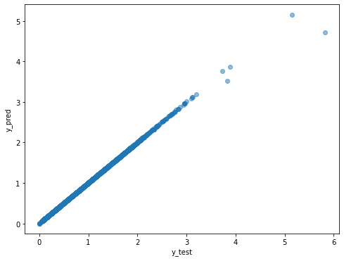

```python
model.fit(Xtr,Ytr)
Ypred=model.predict(Xts)
lin_r = r2_score(Yts, Ypred)
# plotting actual vs prediction
plt.scatter(Yts, Ypred, alpha = 0.5)
plt.xlabel("y_test")
plt.ylabel("y_pred")
plt.show()
```

```python
predictions = model.predict(test_set)
predictions
```

```
array([1.3856962 , 1.7139647 , 1.255728  , ..., 2.1278467 , 0.16979732,
       0.34494576], dtype=float32)
```

```python
r2 = metrics.r2_score(Yts, Ypred)
r2
```

```
0.9987454476516002
```

##### 4.1 Feature importance

Now let's explore the feature importance on the model performance.

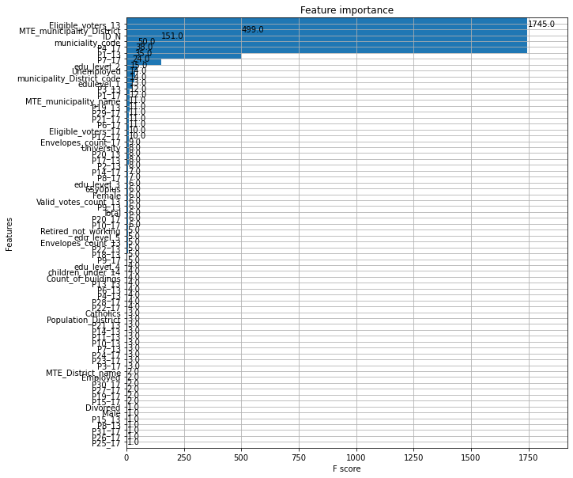

```python
from xgboost import plot_importance
figsize=(10,10)
fig, ax = plt.subplots(1,1,figsize=figsize)
plot_importance(model, ax=ax,height = 10)
```

#### 4.2 Hyperparameters research

We use so called fine tuning to find the best parameters for our model. We decide to use HalvingRandomSearchCV.

```python
from sklearn.experimental import enable_halving_search_cv
from sklearn.model_selection import HalvingRandomSearchCV
from scipy.stats import expon
import warnings
warnings.filterwarnings("ignore")
```

```python
params_dist = [
    {
        'max_depth': [2, 3, 5, 8, 16],
        'criterion': ['gini', 'entropy'],
        'min_samples_split': np.unique(np.logspace(1, 4, num=30, dtype=np.int)),
        'ccp_alpha': expon(scale=0.00025),
        "learning_rate" : [0.05,0.10,0.15],
        "gamma": [ 0.0, 0.1, 0.2 ]
    }
]

tree = XGBRegressor(randon_state=RANDOM_STATE)

clf = HalvingRandomSearchCV(
    estimator=tree,
    param_distributions=params_dist,
    n_candidates=50,
    factor=2,
    resource='n_samples',
    min_resources='exhaust',
    cv=3,
    scoring='r2',
    error_score=0,
    refit=True,
    random_state=RANDOM_STATE
)

clf.fit(Xtr, Ytr)
```

[output not shown]

[output cut: 2375 more lines]

[output not shown]

[output not shown]

The hyperparameters reseacrh show that the best parameters for our modelling are following:

```python
clf.best_params_
```

```
{'ccp_alpha': 0.00043575554549239335,
 'criterion': 'gini',
 'gamma': 0.0,
 'learning_rate': 0.15,
 'max_depth': 8,
 'min_samples_split': 16}
```

```python
pd.DataFrame(clf.cv_results_).head()
```

|  | iter | n_resources | mean_fit_time | std_fit_time | mean_score_time | std_score_time | param_ccp_alpha | param_criterion | param_gamma | param_learning_rate | param_max_depth | param_min_samples_split | params | split0_test_score | split1_test_score | split2_test_score | mean_test_score | std_test_score | rank_test_score | split0_train_score | split1_train_score | split2_train_score | mean_train_score | std_train_score |
| --- | --- | --- | --- | --- | --- | --- | --- | --- | --- | --- | --- | --- | --- | --- | --- | --- | --- | --- | --- | --- | --- | --- | --- | --- |
| 0 | 0 | 295 | 0.15 | 4.16e-02 | 3.17e-03 | 1.42e-04 | 0.0 | gini | 0.1 | 0.1 | 5 | 20 | {'ccp_alpha': 4.185710574647497e-05, 'criterio... | 1.0 | 0.35 | 0.96 | 0.77 | 0.30 | 38 | 1.00 | 1.00 | 1.0 | 1.00 | 6.98e-04 |
| 1 | 0 | 295 | 0.22 | 3.74e-03 | 3.41e-03 | 1.22e-04 | 0.0 | gini | 0.2 | 0.1 | 16 | 32 | {'ccp_alpha': 0.00032147817783043163, 'criteri... | 1.0 | 0.34 | 0.96 | 0.77 | 0.30 | 67 | 0.99 | 0.99 | 1.0 | 0.99 | 1.27e-03 |
| 2 | 0 | 295 | 0.09 | 6.40e-03 | 3.16e-03 | 2.28e-04 | 0.0 | gini | 0.2 | 0.15 | 2 | 1487 | {'ccp_alpha': 8.498171963927468e-06, 'criterio... | 1.0 | 0.34 | 0.96 | 0.77 | 0.30 | 72 | 0.99 | 0.99 | 1.0 | 0.99 | 1.62e-03 |
| 3 | 0 | 295 | 0.16 | 1.75e-03 | 3.08e-03 | 4.30e-05 | 0.0 | entropy | 0.2 | 0.1 | 8 | 25 | {'ccp_alpha': 0.00023290387994727609, 'criteri... | 1.0 | 0.34 | 0.96 | 0.77 | 0.30 | 67 | 0.99 | 0.99 | 1.0 | 0.99 | 1.27e-03 |
| 4 | 0 | 295 | 0.12 | 2.98e-03 | 3.13e-03 | 4.45e-05 | 0.0 | gini | 0.0 | 0.15 | 5 | 452 | {'ccp_alpha': 0.00018413166651240812, 'criteri... | 1.0 | 0.41 | 0.97 | 0.79 | 0.27 | 28 | 1.00 | 1.00 | 1.0 | 1.00 | 2.38e-07 |

```python
cvres = pd.DataFrame(clf.cv_results_)

cvres.groupby('iter')['iter'].count()
```

```
iter
0    50
1    25
2    13
3     7
4     4
5     2
Name: iter, dtype: int64
```

Let's plot the results from the hyperparameters research and the r2_score at each iteration.

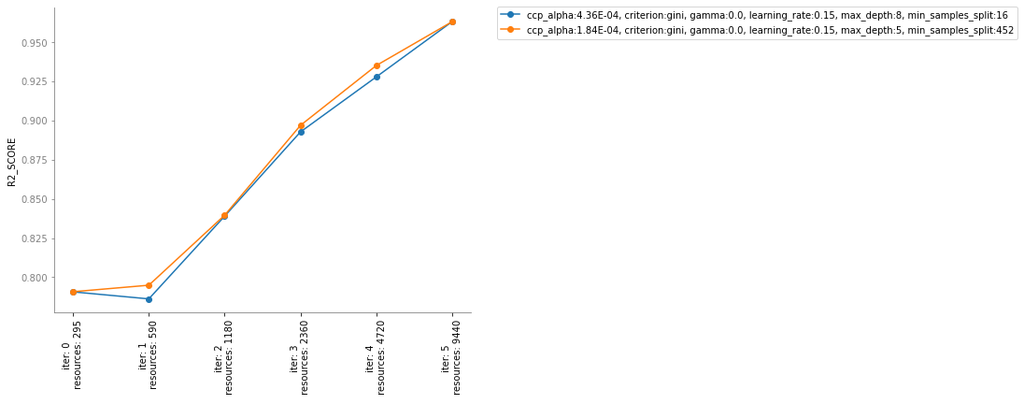

```python
cvres = pd.DataFrame(clf.cv_results_)
param_combs = cvres[cvres['iter'] == 5]['params'].to_list()

cvres_res = pd.DataFrame()
ax = plt.subplot(1,1,1)
for pc in param_combs:
    dt = cvres[cvres['params'] == pc]
    label = ', '.join([f'{p}:{v:.2E}' if p=='ccp_alpha' else f'{p}:{v}' for p,v in pc.items()])
    ax.plot(dt['iter'], dt['mean_test_score'], marker='o', label=label)

ax.set_xticks(dt['iter'])
ax.set_xticklabels(
    cvres[['iter', 'n_resources']].drop_duplicates().apply(lambda row: f'iter: {row[0]}\n resources: {row[1]}', axis = 1).to_list(),
    rotation=90
)

ax.legend(bbox_to_anchor=(1.05, 1.02))
ax.set_ylabel('R2_SCORE')
ax.tick_params(axis='y', colors='gray')
ax.spines['top'].set_visible(False)
ax.spines['right'].set_visible(False)
ax.spines['left'].set_color('gray')
ax.spines['bottom'].set_color('gray')
plt.show()
```

```python
xgb_model_tuned=clf
xgb_model_tuned.best_params_
```

```
{'ccp_alpha': 0.00043575554549239335,
 'criterion': 'gini',
 'gamma': 0.0,
 'learning_rate': 0.15,
 'max_depth': 8,
 'min_samples_split': 16}
```

#### 4.3 Final Model

After finetuning we build our final model using finetuned parameters.

```python
from sklearn import metrics
#Validation data
val_data=data.drop(columns=col_target)
final_target=data[col_target]
predictions=xgb_model_tuned.predict(val_data)
r2 = metrics.r2_score(final_target, predictions)
r2
```

```
0.9930386733461537
```

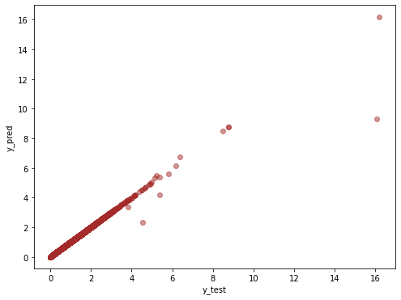

```python
lin_r = metrics.r2_score(final_target, predictions)
# plotting actual vs prediction
plt.scatter(final_target, predictions, color="brown", alpha = 0.5)
plt.xlabel("y_test")
plt.ylabel("y_pred")
plt.show()
```

##### 6. Conclusion

Author: Doudou BA  
E-mail: presidou@gmail.com